# Westhoff, Max

On my honor, as a student, I have neither given nor received unauthorized aid on this academic work.

```python
#import python packages (these are the most popular ones)
import pandas as pd
import numpy as np
import matplotlib.pyplot as plt
import seaborn as sns
import math as mth
import statsmodels.formula.api as sm\

%matplotlib inline
```

```python
#Loading imdb-5000-movie-dataset
df = pd.read_csv("data/movie_metadata.csv")
df.head()
```

|  | color | director_name | num_critic_for_reviews | duration | director_facebook_likes | actor_3_facebook_likes | actor_2_name | actor_1_facebook_likes | gross | genres | ... | num_user_for_reviews | language | country | content_rating | budget | title_year | actor_2_facebook_likes | imdb_score | aspect_ratio | movie_facebook_likes |
| --- | --- | --- | --- | --- | --- | --- | --- | --- | --- | --- | --- | --- | --- | --- | --- | --- | --- | --- | --- | --- | --- |
| 0 | Color | James Cameron | 723.0 | 178.0 | 0.0 | 855.0 | Joel David Moore | 1000.0 | 760505847.0 | Action\|Adventure\|Fantasy\|Sci-Fi | ... | 3054.0 | English | USA | PG-13 | 237000000.0 | 2009.0 | 936.0 | 7.9 | 1.78 | 33000 |
| 1 | Color | Gore Verbinski | 302.0 | 169.0 | 563.0 | 1000.0 | Orlando Bloom | 40000.0 | 309404152.0 | Action\|Adventure\|Fantasy | ... | 1238.0 | English | USA | PG-13 | 300000000.0 | 2007.0 | 5000.0 | 7.1 | 2.35 | 0 |
| 2 | Color | Sam Mendes | 602.0 | 148.0 | 0.0 | 161.0 | Rory Kinnear | 11000.0 | 200074175.0 | Action\|Adventure\|Thriller | ... | 994.0 | English | UK | PG-13 | 245000000.0 | 2015.0 | 393.0 | 6.8 | 2.35 | 85000 |
| 3 | Color | Christopher Nolan | 813.0 | 164.0 | 22000.0 | 23000.0 | Christian Bale | 27000.0 | 448130642.0 | Action\|Thriller | ... | 2701.0 | English | USA | PG-13 | 250000000.0 | 2012.0 | 23000.0 | 8.5 | 2.35 | 164000 |
| 4 | NaN | Doug Walker | NaN | NaN | 131.0 | NaN | Rob Walker | 131.0 | NaN | Documentary | ... | NaN | NaN | NaN | NaN | NaN | NaN | 12.0 | 7.1 | NaN | 0 |

5 rows × 28 columns

## Business Understanding section

Data analytics is a new field in business that has become a must in terms of backing up your business decisions with preprocessed data and predictions that are as accurate as one can make them.

The need to understand how choices can predict movies success, has driven the film industry to gather and manipulate data for business decision optimization and to get an aggregated advantage over competitors.

Unfortunately, all this work my not guarantee the success of a movie. Having establish that, this is my business understanding of this issue.

#### What are the Project's goals?

The Project's goals are to determine if the movies were a success or not

#### If you’re hired as a data/business analyst to predict how well a movie will perform in theaters, what kind of data would you collect?

##### The data that I would collect are:

Categorical data:

- The movie title
- The duration of the movie
- The director's name
- The main actor's name
- The year in which the movie was released
- The genre of the movie
- Color of the movie (Black and White or Color picture)
- Language of the movie
- Country where the movie was made

Numerical data:

- Number of users that gave a review
- Number of critical reviews on imdb
- Content rating of the movie
- Gross earnings of the movie
- Budget of the movie
- IMDB rating score for the movie

#### What variables are highly correlated to imdb score? In this project, you will use imdb_score to measure a movie’s success.

To determine which variables are correlated to imdb score we need to perform a correlation analysis, but before doing that we need to understand the data that we are going to analyze. Then, we clean the data to get rid of duplicates, drop missing values, change the datatypes of the values in the dataset, etc. After cleaning our dataset, we can perform our analysis on the data and reach to several conclusions.

Next, we begin to understand our data.

## Data Understanding section

```python
#Description of the data
df.describe()
```

|  | num_critic_for_reviews | duration | director_facebook_likes | actor_3_facebook_likes | actor_1_facebook_likes | gross | num_voted_users | cast_total_facebook_likes | facenumber_in_poster | num_user_for_reviews | budget | title_year | actor_2_facebook_likes | imdb_score | aspect_ratio | movie_facebook_likes |
| --- | --- | --- | --- | --- | --- | --- | --- | --- | --- | --- | --- | --- | --- | --- | --- | --- |
| count | 4993.000000 | 5028.000000 | 4939.000000 | 5020.000000 | 5036.000000 | 4.159000e+03 | 5.043000e+03 | 5043.000000 | 5030.000000 | 5022.000000 | 4.551000e+03 | 4935.000000 | 5030.000000 | 5043.000000 | 4714.000000 | 5043.000000 |
| mean | 140.194272 | 107.201074 | 686.509212 | 645.009761 | 6560.047061 | 4.846841e+07 | 8.366816e+04 | 9699.063851 | 1.371173 | 272.770808 | 3.975262e+07 | 2002.470517 | 1651.754473 | 6.442138 | 2.220403 | 7525.964505 |
| std | 121.601675 | 25.197441 | 2813.328607 | 1665.041728 | 15020.759120 | 6.845299e+07 | 1.384853e+05 | 18163.799124 | 2.013576 | 377.982886 | 2.061149e+08 | 12.474599 | 4042.438863 | 1.125116 | 1.385113 | 19320.445110 |
| min | 1.000000 | 7.000000 | 0.000000 | 0.000000 | 0.000000 | 1.620000e+02 | 5.000000e+00 | 0.000000 | 0.000000 | 1.000000 | 2.180000e+02 | 1916.000000 | 0.000000 | 1.600000 | 1.180000 | 0.000000 |
| 25% | 50.000000 | 93.000000 | 7.000000 | 133.000000 | 614.000000 | 5.340988e+06 | 8.593500e+03 | 1411.000000 | 0.000000 | 65.000000 | 6.000000e+06 | 1999.000000 | 281.000000 | 5.800000 | 1.850000 | 0.000000 |
| 50% | 110.000000 | 103.000000 | 49.000000 | 371.500000 | 988.000000 | 2.551750e+07 | 3.435900e+04 | 3090.000000 | 1.000000 | 156.000000 | 2.000000e+07 | 2005.000000 | 595.000000 | 6.600000 | 2.350000 | 166.000000 |
| 75% | 195.000000 | 118.000000 | 194.500000 | 636.000000 | 11000.000000 | 6.230944e+07 | 9.630900e+04 | 13756.500000 | 2.000000 | 326.000000 | 4.500000e+07 | 2011.000000 | 918.000000 | 7.200000 | 2.350000 | 3000.000000 |
| max | 813.000000 | 511.000000 | 23000.000000 | 23000.000000 | 640000.000000 | 7.605058e+08 | 1.689764e+06 | 656730.000000 | 43.000000 | 5060.000000 | 1.221550e+10 | 2016.000000 | 137000.000000 | 9.500000 | 16.000000 | 349000.000000 |

```python
#Identifying data quality issues
df.isnull().sum()
```

```
color                         19
director_name                104
num_critic_for_reviews        50
duration                      15
director_facebook_likes      104
actor_3_facebook_likes        23
actor_2_name                  13
actor_1_facebook_likes         7
gross                        884
genres                         0
actor_1_name                   7
movie_title                    0
num_voted_users                0
cast_total_facebook_likes      0
actor_3_name                  23
facenumber_in_poster          13
plot_keywords                153
movie_imdb_link                0
num_user_for_reviews          21
language                      12
country                        5
content_rating               303
budget                       492
title_year                   108
actor_2_facebook_likes        13
imdb_score                     0
aspect_ratio                 329
movie_facebook_likes           0
dtype: int64
```

```python
#identify data types
df.info()
```

```
<class 'pandas.core.frame.DataFrame'>
RangeIndex: 5043 entries, 0 to 5042
Data columns (total 28 columns):
color                        5024 non-null object
director_name                4939 non-null object
num_critic_for_reviews       4993 non-null float64
duration                     5028 non-null float64
director_facebook_likes      4939 non-null float64
actor_3_facebook_likes       5020 non-null float64
actor_2_name                 5030 non-null object
actor_1_facebook_likes       5036 non-null float64
gross                        4159 non-null float64
genres                       5043 non-null object
actor_1_name                 5036 non-null object
movie_title                  5043 non-null object
num_voted_users              5043 non-null int64
cast_total_facebook_likes    5043 non-null int64
actor_3_name                 5020 non-null object
facenumber_in_poster         5030 non-null float64
plot_keywords                4890 non-null object
movie_imdb_link              5043 non-null object
num_user_for_reviews         5022 non-null float64
language                     5031 non-null object
country                      5038 non-null object
content_rating               4740 non-null object
budget                       4551 non-null float64
title_year                   4935 non-null float64
actor_2_facebook_likes       5030 non-null float64
imdb_score                   5043 non-null float64
aspect_ratio                 4714 non-null float64
movie_facebook_likes         5043 non-null int64
dtypes: float64(13), int64(3), object(12)
memory usage: 1.1+ MB
```

Conclusion: Not all the variables have 5043 filled rows. There is a lot of missing data between these columns

```python
#Identifying value counts for columns that are considered important to predic movie success
df['num_critic_for_reviews'].value_counts().head(10)
```

```
1.0     43
9.0     37
5.0     36
10.0    35
8.0     35
12.0    34
16.0    33
81.0    33
43.0    31
29.0    30
Name: num_critic_for_reviews, dtype: int64
```

```python
df['duration'].value_counts().head(10)
```

```
90.0     161
100.0    141
101.0    139
98.0     135
97.0     131
93.0     129
94.0     124
99.0     124
95.0     124
96.0     113
Name: duration, dtype: int64
```

```python
df['num_voted_users'].value_counts().head(10)
```

```
57      5
6       4
6025    3
374     3
53      3
3119    3
62      3
162     3
2541    3
8       3
Name: num_voted_users, dtype: int64
```

```python
df['num_user_for_reviews'].value_counts().head(10)
```

```
1.0     51
3.0     33
2.0     32
26.0    32
10.0    29
6.0     28
50.0    26
8.0     25
32.0    25
11.0    24
Name: num_user_for_reviews, dtype: int64
```

```python
df['imdb_score'].value_counts().head(10)
```

```
6.7    223
6.6    201
7.2    195
6.5    186
6.4    185
7.3    184
7.0    184
7.1    181
6.8    181
6.1    179
Name: imdb_score, dtype: int64
```

## Data Preparation Section

### Summary:

- Removing missing values
- Dropping columns that do not predict the IMDB score
- Finding out how many duplicate entries in the dataset
- Dropping duplicate entries
- Creating new column under the name profit to find out the most profitable movie
- Saving changes into a new csv file for further use

```python
#Removing missing values from our dataset
df = df.dropna()
df.info()
```

```
<class 'pandas.core.frame.DataFrame'>
Int64Index: 3756 entries, 0 to 5042
Data columns (total 28 columns):
color                        3756 non-null object
director_name                3756 non-null object
num_critic_for_reviews       3756 non-null float64
duration                     3756 non-null float64
director_facebook_likes      3756 non-null float64
actor_3_facebook_likes       3756 non-null float64
actor_2_name                 3756 non-null object
actor_1_facebook_likes       3756 non-null float64
gross                        3756 non-null float64
genres                       3756 non-null object
actor_1_name                 3756 non-null object
movie_title                  3756 non-null object
num_voted_users              3756 non-null int64
cast_total_facebook_likes    3756 non-null int64
actor_3_name                 3756 non-null object
facenumber_in_poster         3756 non-null float64
plot_keywords                3756 non-null object
movie_imdb_link              3756 non-null object
num_user_for_reviews         3756 non-null float64
language                     3756 non-null object
country                      3756 non-null object
content_rating               3756 non-null object
budget                       3756 non-null float64
title_year                   3756 non-null float64
actor_2_facebook_likes       3756 non-null float64
imdb_score                   3756 non-null float64
aspect_ratio                 3756 non-null float64
movie_facebook_likes         3756 non-null int64
dtypes: float64(13), int64(3), object(12)
memory usage: 851.0+ KB
```

```python
#Dropping the columns that do not predict the IMDB rating score
df = df.drop(['movie_imdb_link','facenumber_in_poster','actor_3_facebook_likes'], axis=1)
df.head()
```

|  | color | director_name | num_critic_for_reviews | duration | director_facebook_likes | actor_2_name | actor_1_facebook_likes | gross | genres | actor_1_name | ... | num_user_for_reviews | language | country | content_rating | budget | title_year | actor_2_facebook_likes | imdb_score | aspect_ratio | movie_facebook_likes |
| --- | --- | --- | --- | --- | --- | --- | --- | --- | --- | --- | --- | --- | --- | --- | --- | --- | --- | --- | --- | --- | --- |
| 0 | Color | James Cameron | 723.0 | 178.0 | 0.0 | Joel David Moore | 1000.0 | 760505847.0 | Action\|Adventure\|Fantasy\|Sci-Fi | CCH Pounder | ... | 3054.0 | English | USA | PG-13 | 237000000.0 | 2009.0 | 936.0 | 7.9 | 1.78 | 33000 |
| 1 | Color | Gore Verbinski | 302.0 | 169.0 | 563.0 | Orlando Bloom | 40000.0 | 309404152.0 | Action\|Adventure\|Fantasy | Johnny Depp | ... | 1238.0 | English | USA | PG-13 | 300000000.0 | 2007.0 | 5000.0 | 7.1 | 2.35 | 0 |
| 2 | Color | Sam Mendes | 602.0 | 148.0 | 0.0 | Rory Kinnear | 11000.0 | 200074175.0 | Action\|Adventure\|Thriller | Christoph Waltz | ... | 994.0 | English | UK | PG-13 | 245000000.0 | 2015.0 | 393.0 | 6.8 | 2.35 | 85000 |
| 3 | Color | Christopher Nolan | 813.0 | 164.0 | 22000.0 | Christian Bale | 27000.0 | 448130642.0 | Action\|Thriller | Tom Hardy | ... | 2701.0 | English | USA | PG-13 | 250000000.0 | 2012.0 | 23000.0 | 8.5 | 2.35 | 164000 |
| 5 | Color | Andrew Stanton | 462.0 | 132.0 | 475.0 | Samantha Morton | 640.0 | 73058679.0 | Action\|Adventure\|Sci-Fi | Daryl Sabara | ... | 738.0 | English | USA | PG-13 | 263700000.0 | 2012.0 | 632.0 | 6.6 | 2.35 | 24000 |

5 rows × 25 columns

```python
#Finding out how many duplicate entries in the dataset
df.duplicated().sum()
```

```
33
```

```python
#Dropping duplicate entries
df.drop_duplicates(keep='first', inplace=True)
```

```python
#Checking if any duplicates are left
df.duplicated().sum()
```

```
0
```

```python
#Checking the datatype of the columns
df.info()
```

```
<class 'pandas.core.frame.DataFrame'>
Int64Index: 3723 entries, 0 to 5042
Data columns (total 25 columns):
color                        3723 non-null object
director_name                3723 non-null object
num_critic_for_reviews       3723 non-null float64
duration                     3723 non-null float64
director_facebook_likes      3723 non-null float64
actor_2_name                 3723 non-null object
actor_1_facebook_likes       3723 non-null float64
gross                        3723 non-null float64
genres                       3723 non-null object
actor_1_name                 3723 non-null object
movie_title                  3723 non-null object
num_voted_users              3723 non-null int64
cast_total_facebook_likes    3723 non-null int64
actor_3_name                 3723 non-null object
plot_keywords                3723 non-null object
num_user_for_reviews         3723 non-null float64
language                     3723 non-null object
country                      3723 non-null object
content_rating               3723 non-null object
budget                       3723 non-null float64
title_year                   3723 non-null float64
actor_2_facebook_likes       3723 non-null float64
imdb_score                   3723 non-null float64
aspect_ratio                 3723 non-null float64
movie_facebook_likes         3723 non-null int64
dtypes: float64(11), int64(3), object(11)
memory usage: 756.2+ KB
```

```python
#Changing the profit,column to numerical values
df[['title_year','imdb_score','actor_2_facebook_likes','budget','num_user_for_reviews','gross','budget','duration','director_facebook_likes','actor_1_likes','num_critic_for_reviews']] = df[['title_year','imdb_score','actor_2_facebook_likes','budget','num_user_for_reviews','gross','budget','duration','director_facebook_likes','actor_1_facebook_likes','num_critic_for_reviews']].astype(int)
df.info()
```

```
<class 'pandas.core.frame.DataFrame'>
Int64Index: 3723 entries, 0 to 5042
Data columns (total 26 columns):
color                        3723 non-null object
director_name                3723 non-null object
num_critic_for_reviews       3723 non-null int64
duration                     3723 non-null int64
director_facebook_likes      3723 non-null int64
actor_2_name                 3723 non-null object
actor_1_facebook_likes       3723 non-null float64
gross                        3723 non-null int64
genres                       3723 non-null object
actor_1_name                 3723 non-null object
movie_title                  3723 non-null object
num_voted_users              3723 non-null int64
cast_total_facebook_likes    3723 non-null int64
actor_3_name                 3723 non-null object
plot_keywords                3723 non-null object
num_user_for_reviews         3723 non-null int64
language                     3723 non-null object
country                      3723 non-null object
content_rating               3723 non-null object
budget                       3723 non-null int64
title_year                   3723 non-null int64
actor_2_facebook_likes       3723 non-null int64
imdb_score                   3723 non-null int64
aspect_ratio                 3723 non-null float64
movie_facebook_likes         3723 non-null int64
actor_1_likes                3723 non-null int64
dtypes: float64(2), int64(13), object(11)
memory usage: 785.3+ KB
```

```python
#Creating a profit column
df['profit'] = df['gross'] - df['budget']
df.head()
```

|  | color | director_name | num_critic_for_reviews | duration | director_facebook_likes | actor_2_name | actor_1_facebook_likes | gross | genres | actor_1_name | ... | country | content_rating | budget | title_year | actor_2_facebook_likes | imdb_score | aspect_ratio | movie_facebook_likes | actor_1_likes | profit |
| --- | --- | --- | --- | --- | --- | --- | --- | --- | --- | --- | --- | --- | --- | --- | --- | --- | --- | --- | --- | --- | --- |
| 0 | Color | James Cameron | 723 | 178 | 0 | Joel David Moore | 1000.0 | 760505847 | Action\|Adventure\|Fantasy\|Sci-Fi | CCH Pounder | ... | USA | PG-13 | 237000000 | 2009 | 936 | 7 | 1.78 | 33000 | 1000 | 523505847 |
| 1 | Color | Gore Verbinski | 302 | 169 | 563 | Orlando Bloom | 40000.0 | 309404152 | Action\|Adventure\|Fantasy | Johnny Depp | ... | USA | PG-13 | 300000000 | 2007 | 5000 | 7 | 2.35 | 0 | 40000 | 9404152 |
| 2 | Color | Sam Mendes | 602 | 148 | 0 | Rory Kinnear | 11000.0 | 200074175 | Action\|Adventure\|Thriller | Christoph Waltz | ... | UK | PG-13 | 245000000 | 2015 | 393 | 6 | 2.35 | 85000 | 11000 | -44925825 |
| 3 | Color | Christopher Nolan | 813 | 164 | 22000 | Christian Bale | 27000.0 | 448130642 | Action\|Thriller | Tom Hardy | ... | USA | PG-13 | 250000000 | 2012 | 23000 | 8 | 2.35 | 164000 | 27000 | 198130642 |
| 5 | Color | Andrew Stanton | 462 | 132 | 475 | Samantha Morton | 640.0 | 73058679 | Action\|Adventure\|Sci-Fi | Daryl Sabara | ... | USA | PG-13 | 263700000 | 2012 | 632 | 6 | 2.35 | 24000 | 640 | -190641321 |

5 rows × 27 columns

```python
#saving the changes to the dataset
df.to_csv("data/imdb_scores_cleaned.csv", index=False)
```

## Business Intelligence Section

```
The focus of this section should be on what variables are good predictors for a movie’s success. I'll be using a wide variety of data visualization and business intelligence techniques to determine whether which movies has been a success.
```

### Summary:

- Finding out which movies are the most profitable
- Sorting data in terms of IMDB Score for analysis
  - Finding out top ten director names in terms of IMDB Score
  - Finding out top ten movies in terms of IMDB Score
  - Finding out top ten genres in terms of IMDB Score
- Grouping by Title Year to find out how many movies were made in each Year
- Grouping by IMDB score to find out relationship between the average budget for movies with higher rating
- Grouping by IMDB score to find out relationship between the average gross revenue of movies with higher rating
- Visualizing the relationship between IMDB score and num_voted users

```python
#Loading of our cleaned data set to start the analysis
dfclean = pd.read_csv("data/imdb_scores_cleaned.csv")
dfclean.info()
```

```
<class 'pandas.core.frame.DataFrame'>
RangeIndex: 3723 entries, 0 to 3722
Data columns (total 27 columns):
color                        3723 non-null object
director_name                3723 non-null object
num_critic_for_reviews       3723 non-null int64
duration                     3723 non-null int64
director_facebook_likes      3723 non-null int64
actor_2_name                 3723 non-null object
actor_1_facebook_likes       3723 non-null float64
gross                        3723 non-null int64
genres                       3723 non-null object
actor_1_name                 3723 non-null object
movie_title                  3723 non-null object
num_voted_users              3723 non-null int64
cast_total_facebook_likes    3723 non-null int64
actor_3_name                 3723 non-null object
plot_keywords                3723 non-null object
num_user_for_reviews         3723 non-null int64
language                     3723 non-null object
country                      3723 non-null object
content_rating               3723 non-null object
budget                       3723 non-null int64
title_year                   3723 non-null int64
actor_2_facebook_likes       3723 non-null int64
imdb_score                   3723 non-null int64
aspect_ratio                 3723 non-null float64
movie_facebook_likes         3723 non-null int64
actor_1_likes                3723 non-null int64
profit                       3723 non-null int64
dtypes: float64(2), int64(14), object(11)
memory usage: 785.4+ KB
```

```python
#Sorting values in terms of profit to find out which movie was the most profitable
profitsort=dfclean.sort_values('profit', ascending=False).head()
profitsort['movie_title']
```

```
0                                   Avatar
28                          Jurassic World
25                                 Titanic
2683    Star Wars: Episode IV - A New Hope
2727            E.T. the Extra-Terrestrial
Name: movie_title, dtype: object
```

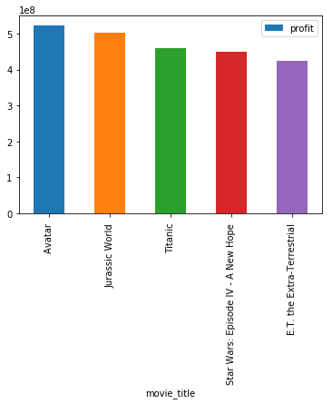

```python
#Plotting of the most profitable movie
profitsorttable = profitsort[['movie_title','profit']].head()
profitsorttable.plot(kind='bar',x='movie_title',y='profit')
```

The top 5 most profitable movies are:

1- Avatar

2- Jurassic World

3- Titanic

4- Star Wars IV: A New Hope

5- E.T. the Extra-Terrestial

```python
#Finding out top ten director names in terms of IMDB Score
```

[output not shown]

```python
#IMDB score sort to determine most successful movies in terms of IMDB score
IMDBscoresort= dfclean.sort_values(by='imdb_score',ascending=False)
IMDBscoresort
```

|  | color | director_name | num_critic_for_reviews | duration | director_facebook_likes | actor_2_name | actor_1_facebook_likes | gross | genres | actor_1_name | ... | country | content_rating | budget | title_year | actor_2_facebook_likes | imdb_score | aspect_ratio | movie_facebook_likes | actor_1_likes | profit |
| --- | --- | --- | --- | --- | --- | --- | --- | --- | --- | --- | --- | --- | --- | --- | --- | --- | --- | --- | --- | --- | --- |
| 1788 | Color | Frank Darabont | 199 | 142 | 0 | Jeffrey DeMunn | 11000.0 | 28341469 | Crime\|Drama | Morgan Freeman | ... | USA | R | 25000000 | 1994 | 745 | 9 | 1.85 | 108000 | 11000 | 3341469 |
| 2983 | Color | Francis Ford Coppola | 208 | 175 | 0 | Marlon Brando | 14000.0 | 134821952 | Crime\|Drama | Al Pacino | ... | USA | R | 6000000 | 1972 | 10000 | 9 | 1.85 | 43000 | 14000 | 128821952 |
| 64 | Color | Christopher Nolan | 645 | 152 | 22000 | Heath Ledger | 23000.0 | 533316061 | Action\|Crime\|Drama\|Thriller | Christian Bale | ... | USA | PG-13 | 185000000 | 2008 | 13000 | 9 | 2.35 | 37000 | 23000 | 348316061 |
| 2527 | Color | Francis Ford Coppola | 149 | 220 | 0 | Al Pacino | 22000.0 | 57300000 | Crime\|Drama | Robert De Niro | ... | USA | R | 13000000 | 1974 | 14000 | 9 | 1.85 | 14000 | 22000 | 44300000 |
| 610 | Color | Steven Spielberg | 219 | 169 | 14000 | Vin Diesel | 15000.0 | 216119491 | Action\|Drama\|War | Tom Hanks | ... | USA | R | 70000000 | 1998 | 14000 | 8 | 1.85 | 22000 | 15000 | 146119491 |
| 3215 | Color | Billy Bob Thornton | 104 | 148 | 0 | Dwight Yoakam | 3000.0 | 24475416 | Drama | Robert Duvall | ... | USA | R | 890000 | 1996 | 324 | 8 | 1.85 | 0 | 3000 | 23585416 |
| 2288 | Color | Peter Weir | 96 | 128 | 608 | Josh Charles | 49000.0 | 95860116 | Comedy\|Drama | Robin Williams | ... | USA | PG | 16400000 | 1989 | 1000 | 8 | 1.85 | 23000 | 49000 | 79460116 |
| 256 | Color | Peter Jackson | 297 | 171 | 0 | Orlando Bloom | 16000.0 | 313837577 | Action\|Adventure\|Drama\|Fantasy | Christopher Lee | ... | New Zealand | PG-13 | 93000000 | 2001 | 5000 | 8 | 2.35 | 21000 | 16000 | 220837577 |
| 264 | Color | Ridley Scott | 568 | 151 | 0 | Donald Glover | 13000.0 | 228430993 | Adventure\|Drama\|Sci-Fi | Matt Damon | ... | USA | PG-13 | 108000000 | 2015 | 801 | 8 | 2.35 | 153000 | 13000 | 120430993 |
| 2730 | Color | Gus Van Sant | 161 | 126 | 835 | Matt Damon | 49000.0 | 138339411 | Drama | Robin Williams | ... | USA | R | 10000000 | 1997 | 13000 | 8 | 1.85 | 31000 | 49000 | 128339411 |
| 2726 | Color | Stanley Kubrick | 285 | 161 | 0 | Gary Lockwood | 273.0 | 56715371 | Adventure\|Mystery\|Sci-Fi | Keir Dullea | ... | UK | G | 12000000 | 1968 | 117 | 8 | 2.20 | 24000 | 273 | 44715371 |
| 268 | Color | Ridley Scott | 265 | 171 | 0 | Connie Nielsen | 3000.0 | 187670866 | Action\|Drama\|Romance | Djimon Hounsou | ... | USA | R | 103000000 | 2000 | 933 | 8 | 2.35 | 21000 | 3000 | 84670866 |
| 3532 | Color | John G. Avildsen | 141 | 145 | 80 | Burgess Meredith | 13000.0 | 117235247 | Drama\|Sport | Sylvester Stallone | ... | USA | PG | 960000 | 1976 | 1000 | 8 | 1.33 | 0 | 13000 | 116275247 |
| 271 | Black and White | Martin Campbell | 400 | 144 | 258 | Tobias Menzies | 6000.0 | 167007184 | Action\|Adventure\|Thriller | Eva Green | ... | UK | PG-13 | 150000000 | 2006 | 1000 | 8 | 2.35 | 0 | 6000 | 17007184 |
| 3523 | Color | Sergio Leone | 181 | 142 | 0 | Luigi Pistilli | 16000.0 | 6100000 | Western | Clint Eastwood | ... | Italy | Approved | 1200000 | 1966 | 34 | 8 | 2.35 | 20000 | 16000 | 4900000 |
| 273 | Color | James Cameron | 210 | 153 | 0 | Jenette Goldstein | 780.0 | 204843350 | Action\|Sci-Fi | Joe Morton | ... | USA | R | 102000000 | 1991 | 604 | 8 | 2.35 | 13000 | 780 | 102843350 |
| 2294 | Black and White | Michel Hazanavicius | 576 | 100 | 405 | Ed Lauter | 996.0 | 44667095 | Comedy\|Drama\|Romance | Bérénice Bejo | ... | France | PG-13 | 15000000 | 2011 | 897 | 8 | 1.33 | 30000 | 996 | 29667095 |
| 1105 | Color | M. Night Shyamalan | 234 | 107 | 0 | Haley Joel Osment | 13000.0 | 293501675 | Drama\|Mystery\|Thriller | Bruce Willis | ... | USA | PG-13 | 40000000 | 1999 | 3000 | 8 | 1.85 | 14000 | 13000 | 253501675 |
| 3522 | Color | Quentin Tarantino | 173 | 99 | 16000 | Steve Buscemi | 16000.0 | 2812029 | Crime\|Drama\|Thriller | Quentin Tarantino | ... | USA | R | 1200000 | 1992 | 12000 | 8 | 2.35 | 19000 | 16000 | 1612029 |
| 3431 | Color | Richard Linklater | 211 | 80 | 0 | Albert Delpy | 50.0 | 5792822 | Drama\|Romance | Vernon Dobtcheff | ... | USA | R | 2700000 | 2004 | 8 | 8 | 1.85 | 13000 | 50 | 3092822 |
| 281 | Color | Quentin Tarantino | 765 | 165 | 16000 | Christoph Waltz | 29000.0 | 162804648 | Drama\|Western | Leonardo DiCaprio | ... | USA | R | 100000000 | 2012 | 11000 | 8 | 2.35 | 199000 | 29000 | 62804648 |
| 2300 | Color | Guillermo del Toro | 406 | 112 | 0 | Maribel Verdú | 634.0 | 37623143 | Drama\|Fantasy\|War | Ivana Baquero | ... | Spain | R | 13500000 | 2006 | 269 | 8 | 1.85 | 27000 | 634 | 24123143 |
| 2245 | Color | James Cameron | 250 | 154 | 0 | Carrie Henn | 2000.0 | 85200000 | Action\|Adventure\|Sci-Fi | Michael Biehn | ... | USA | R | 18500000 | 1986 | 626 | 8 | 1.85 | 18000 | 2000 | 66700000 |
| 3256 | Color | Richard Linklater | 548 | 165 | 0 | Lorelei Linklater | 230.0 | 25359200 | Drama | Ellar Coltrane | ... | USA | R | 4000000 | 2014 | 193 | 8 | 1.85 | 92000 | 230 | 21359200 |
| 1490 | Color | David Fincher | 216 | 127 | 21000 | Brad Pitt | 11000.0 | 100125340 | Crime\|Drama\|Mystery\|Thriller | Morgan Freeman | ... | USA | R | 33000000 | 1995 | 11000 | 8 | 2.35 | 39000 | 11000 | 67125340 |
| 3495 | Black and White | Charles Chaplin | 120 | 87 | 0 | Stanley Blystone | 309.0 | 163245 | Comedy\|Drama\|Family | Paulette Goddard | ... | USA | G | 1500000 | 1936 | 8 | 8 | 1.37 | 0 | 309 | -1336755 |
| 1491 | Color | Neill Blomkamp | 472 | 112 | 662 | Jed Brophy | 2000.0 | 115646235 | Action\|Sci-Fi\|Thriller | Sharlto Copley | ... | South Africa | R | 30000000 | 2009 | 433 | 8 | 1.85 | 22000 | 2000 | 85646235 |
| 1137 | Black and White | Frank Miller | 374 | 147 | 436 | Powers Boothe | 3000.0 | 74098862 | Crime\|Thriller | Rosario Dawson | ... | USA | R | 40000000 | 2005 | 472 | 8 | 1.85 | 13000 | 3000 | 34098862 |
| 1493 | Color | Clint Eastwood | 229 | 138 | 16000 | Spencer Treat Clark | 616.0 | 90135191 | Crime\|Drama\|Mystery\|Thriller | John Doman | ... | USA | R | 25000000 | 2003 | 541 | 8 | 2.35 | 12000 | 616 | 65135191 |
| 1494 | Color | Clint Eastwood | 268 | 132 | 16000 | Morgan Freeman | 16000.0 | 100422786 | Drama\|Sport | Clint Eastwood | ... | USA | PG-13 | 30000000 | 2004 | 11000 | 8 | 2.35 | 14000 | 16000 | 70422786 |
| ... | ... | ... | ... | ... | ... | ... | ... | ... | ... | ... | ... | ... | ... | ... | ... | ... | ... | ... | ... | ... | ... |
| 1545 | Color | John R. Leonetti | 59 | 95 | 40 | Talisa Soto | 663.0 | 35927406 | Action\|Adventure\|Fantasy\|Sci-Fi\|Thriller | Brian Thompson | ... | USA | PG-13 | 30000000 | 1997 | 349 | 3 | 1.85 | 1000 | 663 | 5927406 |
| 2267 | Color | Trent Cooper | 37 | 89 | 0 | Larry the Cable Guy | 690.0 | 15655665 | Comedy\|Romance | Thomas F. Wilson | ... | USA | PG-13 | 4000000 | 2006 | 400 | 3 | 1.33 | 110 | 690 | 11655665 |
| 1554 | Color | Troy Miller | 85 | 85 | 14 | Mimi Rogers | 577.0 | 26096584 | Comedy | Elden Henson | ... | USA | PG-13 | 19000000 | 2003 | 291 | 3 | 1.37 | 1000 | 577 | 7096584 |
| 2273 | Color | Sidney J. Furie | 94 | 134 | 22 | Margot Kidder | 1000.0 | 15681020 | Action\|Adventure\|Family\|Sci-Fi | Jim Broadbent | ... | UK | PG | 17000000 | 1987 | 593 | 3 | 2.35 | 1000 | 1000 | -1318980 |
| 2275 | Color | Jim Goddard | 21 | 97 | 3 | Paul Freeman | 400.0 | 2315683 | Adventure\|Crime\|Drama\|Romance | Victor Wong | ... | UK | PG-13 | 17000000 | 1986 | 193 | 3 | 1.85 | 154 | 400 | -14684317 |
| 1585 | Color | James Wong | 130 | 100 | 70 | Texas Battle | 473.0 | 9353573 | Action\|Adventure\|Fantasy\|Sci-Fi\|Thriller | Ian Whyte | ... | USA | PG | 45000000 | 2009 | 315 | 2 | 2.35 | 0 | 473 | -35646427 |
| 2324 | Color | Kenneth Johnson | 36 | 97 | 34 | Annabeth Gish | 503.0 | 1686429 | Action\|Crime\|Sci-Fi | Charles Napier | ... | USA | PG-13 | 16000000 | 1997 | 489 | 2 | 1.85 | 0 | 503 | -14313571 |
| 844 | Color | Martin Brest | 131 | 121 | 102 | Lenny Venito | 117.0 | 5660084 | Comedy\|Crime\|Romance | Todd Giebenhain | ... | USA | R | 54000000 | 2003 | 62 | 2 | 2.35 | 2000 | 117 | -48339916 |
| 2000 | Color | Aaron Seltzer | 99 | 85 | 64 | Carmen Electra | 3000.0 | 48546578 | Comedy\|Romance | Alyson Hannigan | ... | USA | PG-13 | 20000000 | 2006 | 869 | 2 | 1.85 | 806 | 3000 | 28546578 |
| 3268 | Color | Rick de Oliveira | 52 | 96 | 2 | Alan Taylor | 960.0 | 3713002 | Documentary | Laura Ramsey | ... | USA | R | 8000000 | 2003 | 12 | 2 | 1.85 | 131 | 960 | -4286998 |
| 1898 | Color | Joseph Sargent | 80 | 92 | 114 | Mario Van Peebles | 912.0 | 20763013 | Adventure\|Horror\|Thriller | Judith Barsi | ... | USA | PG-13 | 23000000 | 1987 | 535 | 2 | 2.35 | 0 | 912 | -2236987 |
| 2542 | Color | Bob Clark | 45 | 97 | 84 | Dom DeLuise | 899.0 | 27141959 | Comedy\|Crime\|Family\|Sci-Fi | Kathleen Turner | ... | USA | PG | 18000000 | 1999 | 842 | 2 | 1.85 | 0 | 899 | 9141959 |
| 2104 | Color | Dave Borthwick | 31 | 77 | 3 | Kylie Minogue | 787.0 | 7382993 | Adventure\|Animation\|Comedy\|Family\|Fantasy | Jimmy Fallon | ... | USA | G | 20000000 | 2006 | 690 | 2 | 1.85 | 346 | 787 | -12617007 |
| 2655 | Color | Robert Iscove | 60 | 90 | 7 | Kelly Clarkson | 525.0 | 4922166 | Comedy\|Musical\|Romance | Anika Noni Rose | ... | USA | PG | 12000000 | 2003 | 281 | 2 | 1.85 | 0 | 525 | -7077834 |
| 2114 | Color | Uwe Boll | 148 | 94 | 892 | Darren Shahlavi | 310.0 | 5132655 | Horror\|Sci-Fi | Catherine Lough Haggquist | ... | Canada | R | 20000000 | 2005 | 294 | 2 | 2.35 | 1000 | 310 | -14867345 |
| 467 | Color | Roger Christian | 174 | 119 | 64 | Michael Byrne | 743.0 | 21471685 | Action\|Adventure\|Sci-Fi | Richard Tyson | ... | USA | PG-13 | 44000000 | 2000 | 117 | 2 | 2.35 | 0 | 743 | -22528315 |
| 1540 | Color | Jason Friedberg | 111 | 86 | 82 | Diedrich Bader | 869.0 | 38232624 | Comedy | Carmen Electra | ... | USA | PG-13 | 30000000 | 2008 | 759 | 2 | 1.85 | 0 | 869 | 8232624 |
| 2424 | Color | Steve Gomer | 24 | 76 | 9 | Kyla Pratt | 595.0 | 11144518 | Adventure\|Family | Trevor Morgan | ... | Canada | G | 15000000 | 1998 | 417 | 2 | 1.85 | 436 | 595 | -3855482 |
| 3029 | Color | Alex Zamm | 12 | 95 | 43 | Raquel Welch | 1000.0 | 306715 | Comedy | Taylor Negron | ... | USA | PG-13 | 10000000 | 1998 | 788 | 2 | 1.85 | 724 | 1000 | -9693285 |
| 3015 | Color | Don Michael Paul | 25 | 93 | 70 | Faizon Love | 692.0 | 5694308 | Comedy\|Sport | Jeffrey Jones | ... | USA | PG-13 | 7000000 | 2007 | 585 | 2 | 1.85 | 446 | 692 | -1305692 |
| 2128 | Color | Richard Benjamin | 28 | 80 | 121 | Jane Krakowski | 836.0 | 1646664 | Comedy\|Music | Damon Wayans | ... | USA | R | 20000000 | 2003 | 624 | 2 | 1.85 | 241 | 836 | -18353336 |
| 2903 | Color | Vondie Curtis-Hall | 66 | 104 | 170 | Max Beesley | 736.0 | 4273372 | Drama\|Music\|Romance | Mariah Carey | ... | USA | PG-13 | 22000000 | 2001 | 218 | 2 | 2.35 | 0 | 736 | -17726628 |
| 1840 | Color | Uwe Boll | 143 | 92 | 892 | Udo Kier | 783.0 | 1550000 | Action\|Adventure\|Fantasy\|Horror | Meat Loaf | ... | USA | R | 25000000 | 2005 | 595 | 2 | 2.35 | 937 | 783 | -23450000 |
| 3120 | Color | Preston A. Whitmore II | 25 | 95 | 17 | Wayne Brady | 592.0 | 7009668 | Action\|Sport | Wesley Jonathan | ... | USA | PG-13 | 5600000 | 2006 | 378 | 2 | 1.85 | 244 | 592 | 1409668 |
| 3084 | Color | Fred Savage | 52 | 89 | 0 | Brian Doyle-Murray | 555.0 | 13235267 | Comedy\|Family | Lochlyn Munro | ... | USA | PG | 6000000 | 2007 | 484 | 2 | 1.85 | 256 | 555 | 7235267 |
| 303 | Color | Lawrence Guterman | 78 | 94 | 6 | Traylor Howard | 490.0 | 17010646 | Comedy\|Family\|Fantasy | Jamie Kennedy | ... | USA | PG | 84000000 | 2005 | 294 | 2 | 1.85 | 881 | 490 | -66989354 |
| 2008 | Color | Jason Friedberg | 112 | 93 | 82 | Carmen Electra | 926.0 | 39737645 | Adventure\|Comedy | David Carradine | ... | USA | PG-13 | 20000000 | 2007 | 869 | 2 | 1.85 | 0 | 926 | 19737645 |
| 2099 | Color | Bob Clark | 32 | 88 | 84 | Vanessa Angel | 650.0 | 9109322 | Comedy\|Family\|Sci-Fi | Scott Baio | ... | Germany | PG | 20000000 | 2004 | 384 | 1 | 2.35 | 0 | 650 | -10890678 |
| 2524 | Color | Jon M. Chu | 84 | 115 | 209 | Sean Kingston | 569.0 | 73000942 | Documentary\|Music | Usher Raymond | ... | USA | G | 13000000 | 2011 | 69 | 1 | 1.85 | 62000 | 569 | 60000942 |
| 2073 | Color | Jason Friedberg | 111 | 88 | 82 | Tony Cox | 869.0 | 14174654 | Comedy | Carmen Electra | ... | USA | PG-13 | 25000000 | 2008 | 624 | 1 | 1.85 | 0 | 869 | -10825346 |

3723 rows × 27 columns